# Forecasting in R

# Stationarity and differencing

A *stationary* time series has properties that do not depend on the time component. Thus time series with trend or seasonal components are not stationery.

High ACF often indicates a non-stationary series.

*Differencing* or computing differences between consecutive observations, can make a time series stationary, and can stabilize the mean of the series.

Sometimes second-order differencing (taking the difference of the differenced values) might also be called for. Differencing is accomplished with the `diff()` function.

We can test the need for differencing with the KPSS test (`ur.kpss()`) from the `urca` package. We can also check the number of differences needed with the `ndiffs()` function.

A related function is to check the number of seasonal differences needed, or `nsdiffs().`

```
## [1] 0
```

```
## [1] 1
```

```
##        Jan   Feb   Mar   Apr   May   Jun   Jul   Aug   Sep   Oct   Nov   Dec
## 1959        0.89  0.19  1.06  0.57 -0.13 -1.61 -1.74 -0.97 -0.50  1.48  0.77
## 1960  0.84  0.54  0.61  1.45  1.00 -0.44 -1.42 -2.27 -1.74 -0.32  1.16  1.19
## 1961  0.70  0.81  0.84  0.93  1.11 -0.81 -1.19 -1.79 -1.80  0.33  0.78  0.91
## 1962  0.93  0.62  1.13  0.89  0.43 -0.40 -1.00 -2.20 -1.14 -0.84  1.26  1.00
## 1963  1.05  0.34  0.78  1.52  0.86 -0.77 -1.73 -1.97 -1.56 -0.22  1.08  1.29
## 1964  1.21  0.66  0.67  0.66  0.66 -0.33 -1.46 -1.73 -2.00  0.17  0.82  1.02
## 1965  0.72  1.01  0.45  1.24  0.03 -0.29 -0.66 -2.34 -1.05 -0.52  1.56  0.55
## 1966  1.21  0.97  0.80  1.31  0.37 -0.32 -1.35 -2.04 -1.72 -0.54  1.69  1.24
## 1967  1.30  0.17  0.54  1.37  0.58 -0.90 -1.55 -1.62 -1.66  0.14  1.32  1.24
## 1968  0.60  0.59  0.74  1.13  0.54 -0.20 -1.22 -2.03 -1.77 -0.09  1.07  1.58
## 1969  1.09  0.43  1.21  1.03  0.71 -0.67 -0.82 -2.22 -1.28 -0.60  1.07  1.26
## 1970  0.94  0.93  0.95  1.20 -0.06 -0.41 -1.32 -1.65 -1.60 -0.03  0.95  1.11
## 1971  1.05  0.50  0.50  0.61  1.14 -0.36 -1.20 -1.93 -2.07  0.20  1.23  1.22
## 1972  0.75  0.87  0.11  1.98  0.34 -0.98 -1.04 -1.72 -1.48  0.36  1.30  1.05
```

[output cut: 25 more lines]

```
## [1] 0
```

```
##
## #######################
## # KPSS Unit Root Test #
## #######################
##
## Test is of type: mu with 5 lags.
##
## Value of test-statistic is: 7.8173
##
## Critical value for a significance level of:
##                 10pct  5pct 2.5pct  1pct
## critical values 0.347 0.463  0.574 0.739
```

```
##
## #######################
## # KPSS Unit Root Test #
## #######################
##
## Test is of type: mu with 4 lags.
##
## Value of test-statistic is: 0.0701
##
## Critical value for a significance level of:
##                 10pct  5pct 2.5pct  1pct
## critical values 0.347 0.463  0.574 0.739
```

```
##
## #######################
## # KPSS Unit Root Test #
## #######################
##
## Test is of type: mu with 5 lags.
##
## Value of test-statistic is: 0.0124
##
## Critical value for a significance level of:
##                 10pct  5pct 2.5pct  1pct
## critical values 0.347 0.463  0.574 0.739
```

```
## [1] 1
```

```
## [1] 0
```

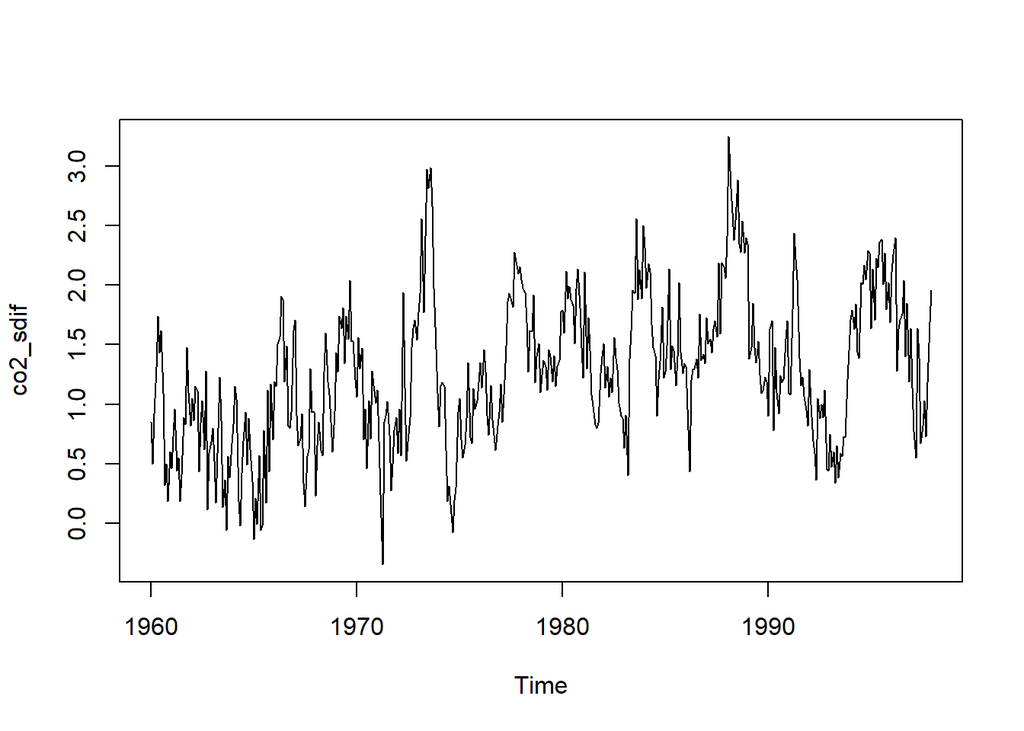

# Linear Models

We can fit a linear regression model using the forecast variable as our ‘y’ or dependent variable, and predictor variables.

For time series, we can use the `tslm` function instead of the `lm` function. This will create a model object with a bit more functionality with respect to time series. However, we could use the `lm` function if we choose. One feature of tslm is that it creates *trend* and *season* components on-the-fly from the time series.

In evaluating the linear model, we will examine the residuals, to check if they are autocorrelated (with an acf plot) and if they are approximately normal and centered around 0 (with a histogram.) The forecast package bundles these nicely into a `checkresiduals` function.

Here, we model the dataset `uschange.`

**`tslm(formula,data)`** fit a time series linear model  
**`checkresiduals(fit)`** convenience function for tsmodel diagnostics

```r
library(fpp2)
head(uschange)
```

```
##         Consumption     Income Production   Savings Unemployment
## 1970 Q1   0.6159862  0.9722610 -2.4527003 4.8103115          0.9
## 1970 Q2   0.4603757  1.1690847 -0.5515251 7.2879923          0.5
## 1970 Q3   0.8767914  1.5532705 -0.3587079 7.2890131          0.5
## 1970 Q4  -0.2742451 -0.2552724 -2.1854549 0.9852296          0.7
## 1971 Q1   1.8973708  1.9871536  1.9097341 3.6577706         -0.1
## 1971 Q2   0.9119929  1.4473342  0.9015358 6.0513418         -0.1
```

```r
fit <- tslm(Consumption ~ Income, data=uschange)
summary(fit)
```

```
##
## Call:
## tslm(formula = Consumption ~ Income, data = uschange)
##
## Residuals:
##      Min       1Q   Median       3Q      Max
## -2.40845 -0.31816  0.02558  0.29978  1.45157
##
## Coefficients:
##             Estimate Std. Error t value Pr(>|t|)
## (Intercept)  0.54510    0.05569   9.789  < 2e-16 ***
## Income       0.28060    0.04744   5.915 1.58e-08 ***
## ---
## Signif. codes:  0 '***' 0.001 '**' 0.01 '*' 0.05 '.' 0.1 ' ' 1
##
## Residual standard error: 0.6026 on 185 degrees of freedom
## Multiple R-squared:  0.159,  Adjusted R-squared:  0.1545
## F-statistic: 34.98 on 1 and 185 DF,  p-value: 1.577e-08
```

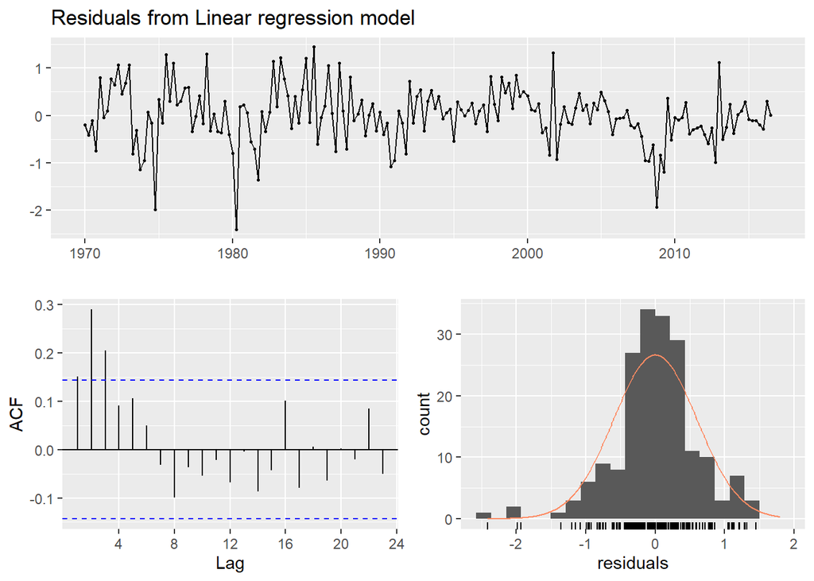

```
##
##  Breusch-Godfrey test for serial correlation of order up to 8
##
## data:  Residuals from Linear regression model
## LM test = 27.422, df = 8, p-value = 0.0005977
```

```r
checkresiduals(fit)
```

# Linear ts components

As mentioned, the `tslm()` function makes it simple to add a number of time-series relevant components to a linear model.

- **`+ trend`** adds a trend component to the model
- **`+ season`** will add seasonal dummy variables to a model. If you have a weekly frequency, for example, it will add indication variables for the days of the week.

Other possible components include **`easter()`** for calculating the effect of the easter holiday, and **`fourier()`** transforms. See the [book](https://otexts.com/fpp2/useful-predictors.html) for more details.

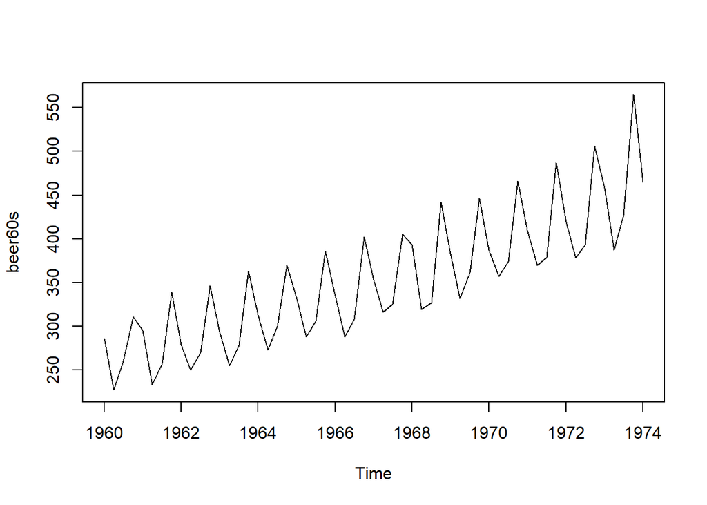

```
##
## Call:
## tslm(formula = beer60s ~ trend)
##
## Residuals:
##     Min      1Q  Median      3Q     Max
## -54.633 -37.000  -4.738  34.054 116.209
##
## Coefficients:
##             Estimate Std. Error t value Pr(>|t|)
## (Intercept) 248.3665    11.3399   21.90  < 2e-16 ***
## trend         3.5790     0.3401   10.52  8.7e-15 ***
## ---
## Signif. codes:  0 '***' 0.001 '**' 0.01 '*' 0.05 '.' 0.1 ' ' 1
##
## Residual standard error: 42.25 on 55 degrees of freedom
## Multiple R-squared:  0.6681, Adjusted R-squared:  0.6621
## F-statistic: 110.7 on 1 and 55 DF,  p-value: 8.704e-15
```

```
## [1] 4
```

```
##
## Call:
## tslm(formula = beer60s ~ trend + season)
##
## Residuals:
##     Min      1Q  Median      3Q     Max
## -19.976  -8.802  -1.193   6.643  57.698
##
## Coefficients:
##             Estimate Std. Error t value Pr(>|t|)
## (Intercept)  259.026      4.624  56.013  < 2e-16 ***
## trend          3.484      0.107  32.561  < 2e-16 ***
## season2      -51.368      4.936 -10.407 2.57e-14 ***
## season3      -33.995      4.935  -6.889 7.44e-09 ***
## season4       53.163      4.936  10.771 7.51e-15 ***
## ---
## Signif. codes:  0 '***' 0.001 '**' 0.01 '*' 0.05 '.' 0.1 ' ' 1
##
## Residual standard error: 13.28 on 52 degrees of freedom
## Multiple R-squared:  0.969,  Adjusted R-squared:  0.9666
## F-statistic: 406.4 on 4 and 52 DF,  p-value: < 2.2e-16
```

# Linear exercise

## Ex.

> Redo the regression model of uschange from above, but use Production as a predictor instead of Income. Make a multiple linear regression with more than one predictor and examine the results.

```
##
## Call:
## tslm(formula = Consumption ~ Production, data = uschange)
##
## Residuals:
##      Min       1Q   Median       3Q      Max
## -1.90407 -0.33583 -0.01253  0.32773  1.79441
##
## Coefficients:
##             Estimate Std. Error t value Pr(>|t|)
## (Intercept)  0.62851    0.04235  14.842  < 2e-16 ***
## Production   0.23218    0.02610   8.895 5.27e-16 ***
## ---
## Signif. codes:  0 '***' 0.001 '**' 0.01 '*' 0.05 '.' 0.1 ' ' 1
##
## Residual standard error: 0.55 on 185 degrees of freedom
## Multiple R-squared:  0.2995, Adjusted R-squared:  0.2958
## F-statistic: 79.11 on 1 and 185 DF,  p-value: 5.272e-16
```

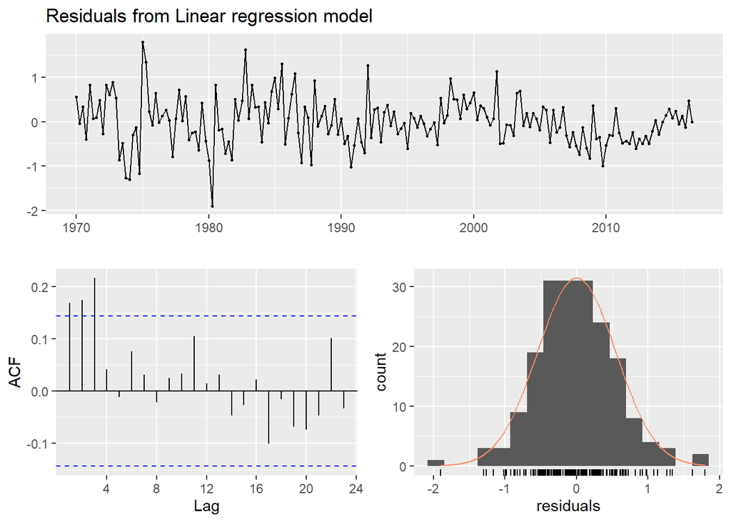

```
##
##  Breusch-Godfrey test for serial correlation of order up to 8
##
## data:  Residuals from Linear regression model
## LM test = 18.797, df = 8, p-value = 0.01599
```

```
##
## Call:
## tslm(formula = Consumption ~ Income + Production + Savings +
##     Unemployment, data = uschange)
##
## Residuals:
##      Min       1Q   Median       3Q      Max
## -0.88296 -0.17638 -0.03679  0.15251  1.20553
##
## Coefficients:
##              Estimate Std. Error t value Pr(>|t|)
## (Intercept)   0.26729    0.03721   7.184 1.68e-11 ***
## Income        0.71449    0.04219  16.934  < 2e-16 ***
## Production    0.04589    0.02588   1.773   0.0778 .
## Savings      -0.04527    0.00278 -16.287  < 2e-16 ***
## Unemployment -0.20477    0.10550  -1.941   0.0538 .
## ---
## Signif. codes:  0 '***' 0.001 '**' 0.01 '*' 0.05 '.' 0.1 ' ' 1
##
## Residual standard error: 0.3286 on 182 degrees of freedom
## Multiple R-squared:  0.754,  Adjusted R-squared:  0.7486
## F-statistic: 139.5 on 4 and 182 DF,  p-value: < 2.2e-16
```

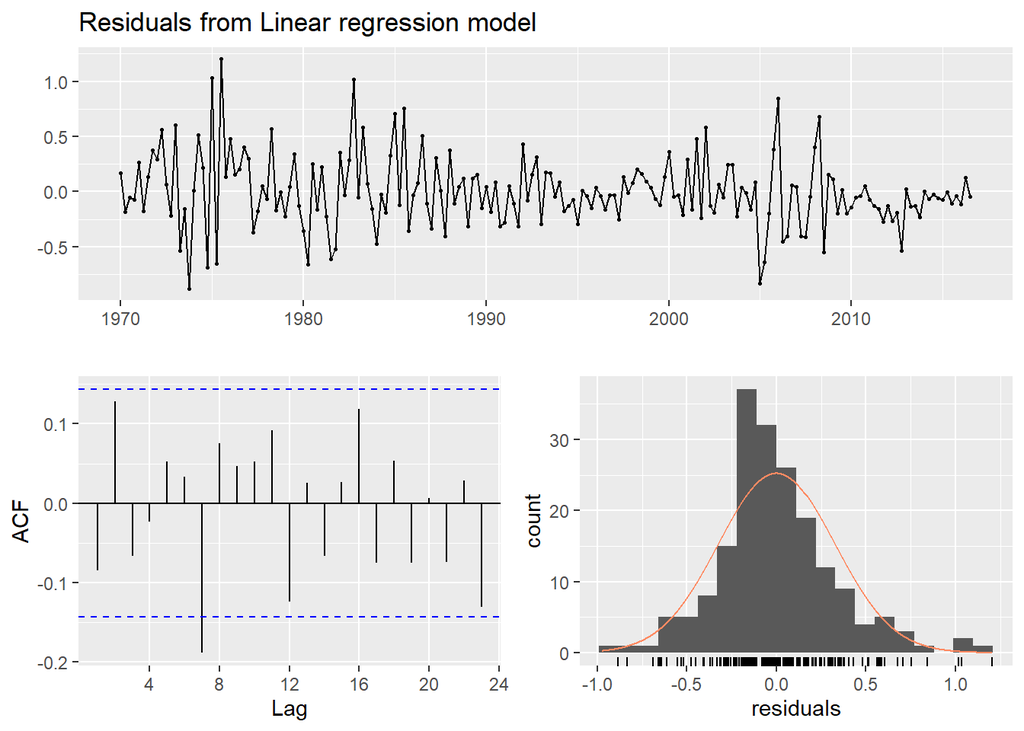

```
##
##  Breusch-Godfrey test for serial correlation of order up to 8
##
## data:  Residuals from Linear regression model
## LM test = 14.874, df = 8, p-value = 0.06163
```

# Regression forecasts

To make forecasts from regression, we distinguish between the kinds of forecasts made by what is known at the time of the forecast.

**Ex-ante** forecasts are made with the data available in advance. To make ex-ante forecasts, we need to create forecasts of the predictors as well. If use seasonal components or calendar time as predictors, we know what these will be in the future.

**Ex-post** forecasts are made using later information from the predictors. These are not “genuine” forecasts, but can use be used to study the behaviour of the models.

We can use the `forecast` method to retrieve forecasts. If we need to supply new data, we can construct that as a data frame.

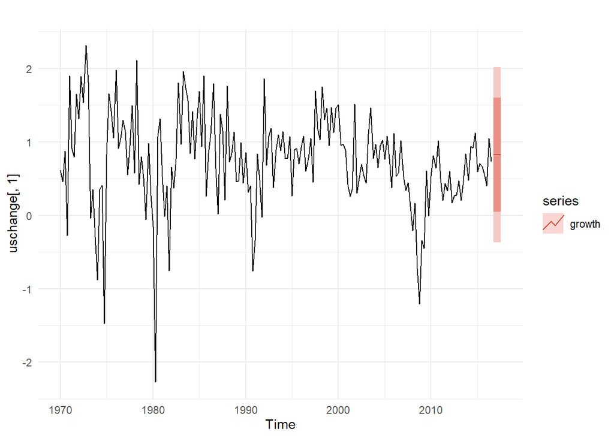

```r
h <- 4
# scenario of constant growth of 1% in Income and 0.5% in Savings
newdata <-
  data.frame(Income = rep(1,h),
                      Production = rep(0,h),
                      Savings = rep(0.5,h),
                      Unemployment = rep(0,h))
fcast <-
  forecast(fit,newdata=newdata)
autoplot(uschange[,1])+autolayer(fcast,PI=T,series="growth")+theme_minimal()
```

# Holt-Winters forecast

We can make a Holt-Winters forecast, which is a forecast based on exponential smoothing and components for season and trend. Holt-Winters has two variants, an additive or a multiplicative method. The multiplicative method is preferred “when seasonal variations are changing proportional to the level of the series,” whereas we use the additive method when “the seasonal component is expressed in absolute terms in the scale of the observed series.”

Here are example methods of Holt-Winters forecasts with the ausbeer data.

```
##         Point Forecast    Lo 80    Hi 80    Lo 95    Hi 95
## 1974 Q2       416.6860 400.4921 432.8799 391.9195 441.4525
## 1974 Q3       442.6915 426.4603 458.9227 417.8680 467.5149
## 1974 Q4       558.9915 542.6768 575.3063 534.0403 583.9428
## 1975 Q1       490.5273 474.0650 506.9896 465.3504 515.7041
## 1975 Q2       441.1985 422.8209 459.5760 413.0923 469.3046
## 1975 Q3       467.2039 448.5327 485.8751 438.6488 495.7590
## 1975 Q4       583.5040 564.4404 602.5675 554.3487 612.6592
## 1976 Q1       515.0397 495.4755 534.6039 485.1189 544.9606
## 1976 Q2       465.7109 443.5694 487.8524 431.8484 499.5734
## 1976 Q3       491.7163 468.9027 514.5300 456.8259 526.6068
```

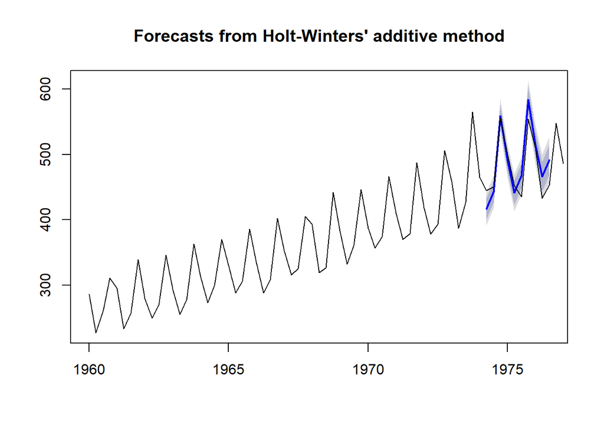

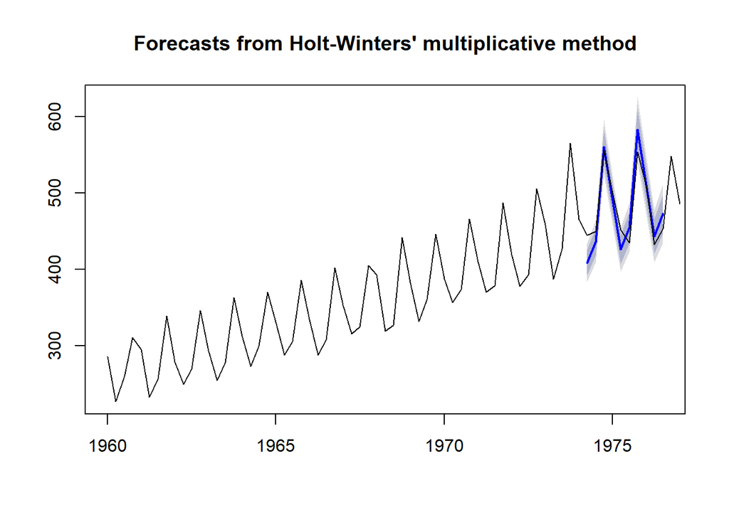

# ETS Model

In fact, Holt-Winters forecasts are related to a family of forecast methods called **ETS** for Error, Trend, Seasonal or **state space models.** Each model can have additive or multiplicative errors.

To choose from all the combinations of ETS models, we can use either AIC (Akaike’s Information Criterion), AICc (“corrected”), or BIC.

To create an ets model, we can use the `ets()` function. Unlike earlier forecast methods, however, this function doesn’t generate point estimates, but estimates model parameters and returns information on the fitted model, much like the `lm` function. If we don’t use any of the optional arguments, ets attempts to automatically fit an appropriate model.

For mathematical details of ETS models, read [here.](https://otexts.com/fpp2/ets.html#tab:ssm)

```
## ETS(M,A,M)
##
## Call:
##  ets(y = beer60s)
##
##   Smoothing parameters:
##     alpha = 0.1891
##     beta  = 0.0257
##     gamma = 1e-04
##
##   Initial states:
##     l = 269.6903
##     b = 2.5933
##     s = 1.1733 0.9279 0.8761 1.0227
##
##   sigma:  0.0311
##
##      AIC     AICc      BIC
## 509.8395 513.6693 528.2270
##
## Training set error measures:
##                    ME     RMSE      MAE       MPE     MAPE      MASE       ACF1
## Training set 1.614983 10.17739 7.895787 0.3284163 2.276111 0.5115852 -0.1606086
```

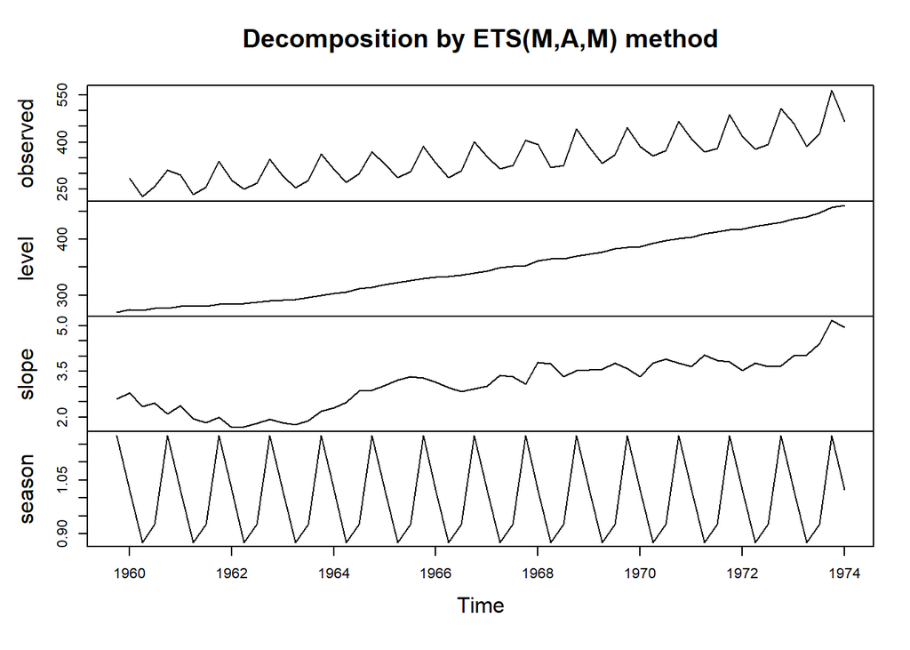

```
##          Qtr1     Qtr2     Qtr3     Qtr4
## 1960 278.4560 242.2057 255.6558 327.1915
## 1961 284.6626 247.6049 261.1231 331.3303
## 1962 292.0882 249.5527 265.9593 339.3569
## 1963 298.8533 256.8135 273.2735 348.8884
## 1964 308.6615 267.1392 286.4165 368.7591
## 1965 324.5579 281.7434 302.6593 387.3920
## 1966 340.7813 293.7491 312.7367 397.6448
## 1967 350.3071 303.1625 326.8089 416.7138
## 1968 364.4195 320.1370 342.3378 433.1176
## 1969 382.5806 330.9086 354.0175 453.7312
## 1970 397.8765 341.9918 368.7217 472.0836
## 1971 414.3275 357.4498 384.8533 489.7762
## 1972 430.3310 369.9044 396.8999 505.2229
## 1973 444.2379 386.3161 413.0515 530.8166
## 1974 473.5871
```

# ETS forecast

To retrieve the forecast from an ETS model, we use the `forecast()` method on our fit, and specify the horizon.

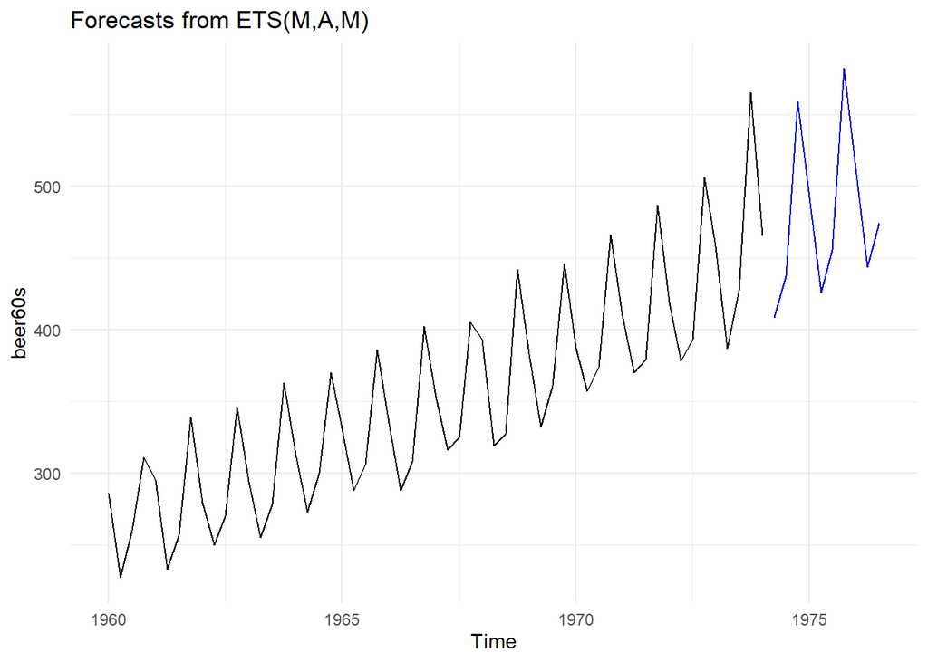

# ARIMA Model

In an **autoregressive model,** we make forecasts using linear combinations of past values of the variable. **Moving average** models forecast uses past forecast errors in a regression-like model. Combining autoregressive and moving average models yields the **ARIMA** model.

To fit an ARIMA model, we can use the `auto.arima` function from the forecast package. There are built in *arima* functions as well in base R. The auto.arima function will try several different models, and choose a best candidate by comparing AIC. You can read details on the algorithm [here.](https://otexts.com/fpp2/arima-r.html)

Here, we fit a model to the `uschange` data using `auto.arima.`

```r
fit_arima1 <-
  auto.arima(uschange[,"Consumption"],
             seasonal = FALSE)
summary(fit_arima1)
```

```
## Series: uschange[, "Consumption"]
## ARIMA(1,0,3) with non-zero mean
##
## Coefficients:
##          ar1      ma1     ma2     ma3    mean
##       0.5885  -0.3528  0.0846  0.1739  0.7454
## s.e.  0.1541   0.1658  0.0818  0.0843  0.0930
##
## sigma^2 estimated as 0.3499:  log likelihood=-164.81
## AIC=341.61   AICc=342.08   BIC=361
##
## Training set error measures:
##                       ME    RMSE       MAE      MPE    MAPE      MASE         ACF1
## Training set 0.001051018 0.58356 0.4306226 49.39042 171.384 0.6746977 -0.001972116
```

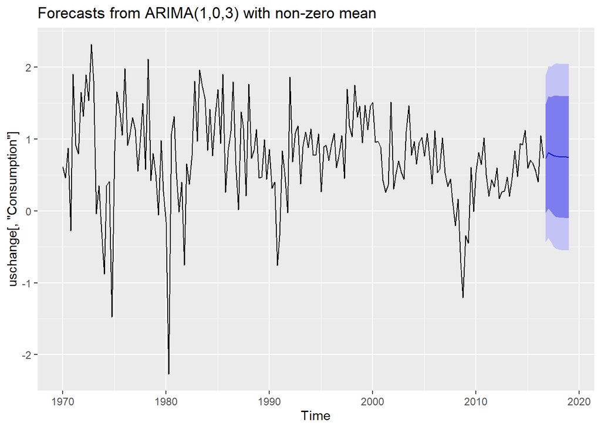

```r
fit_arima1 %>%
  forecast(h=10) %>%
  autoplot()
```

# Arima exercise

Fit an auto.arima model to your mpg_ts data. Make a forecast for future periods h=3 and plot the results. We don’t expect this model to be very good, because the mpg data is in essence noise– we are just using it for demonstration purposes here.

```
## Series: mpg_ts
## ARIMA(3,0,0) with non-zero mean
##
## Coefficients:
##          ar1     ar2      ar3     mean
##       0.4630  0.1525  -0.5500  20.1095
## s.e.  0.1395  0.1621   0.1379   0.8012
##
## sigma^2 estimated as 19.28:  log likelihood=-91.3
## AIC=192.6   AICc=194.91   BIC=199.93
##
## Training set error measures:
##                      ME     RMSE      MAE       MPE     MAPE     MASE        ACF1
## Training set 0.03908198 4.106841 3.011332 -4.653119 17.02515 0.336838 -0.02832793
```

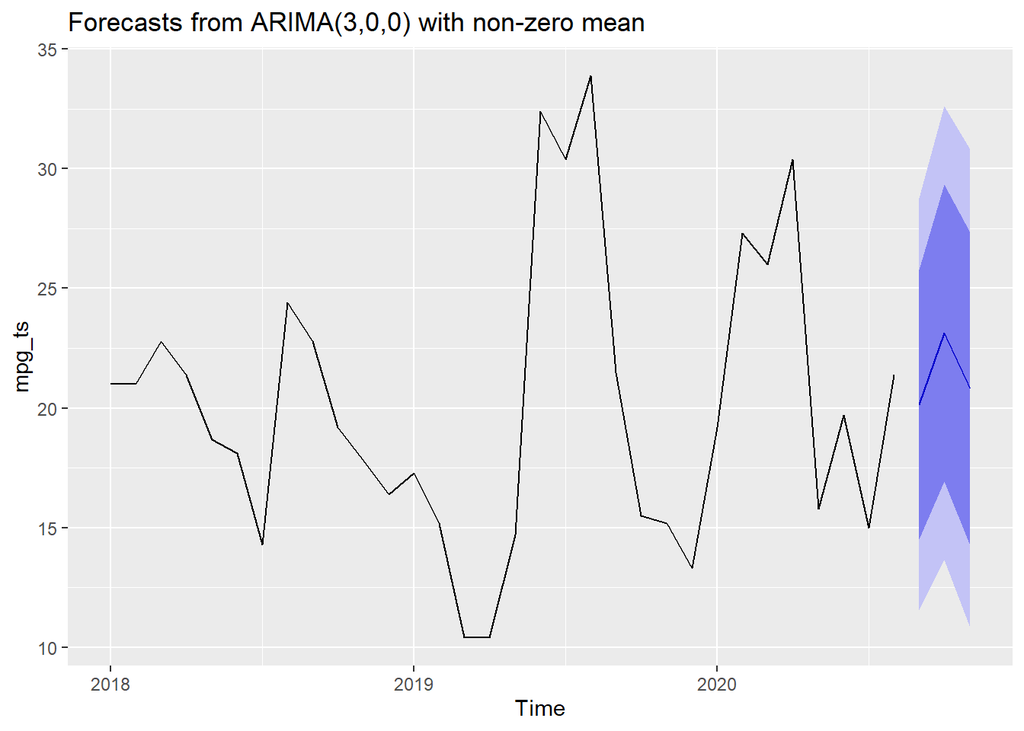

# Conclusion

There are many more methods to explore in the realm of forecasting. There are additional details about ARIMA models to explore, comparisons with ETS, and dynamic regression models and hierarchical time series. We invite you to continue with the *Forecasting* book to explore these advanced topics.